# Guidelines for Better Data Visualizations

2024 Pre-Datathon Workshop

Dr. Weijia Jia

03/21/2024

# Better Data Visualizations

Five guidelines for better data visualizations from Jon Schwabish’s book called [Better Data Visualizations](https://policyviz.com/pv_books/better-data-visualizations-a-guide-for-scholars-researchers-and-wonks/).

- Show the data
- Reduce the clutter
- Integrate the graphics and text
- Avoid the spaghetti chart
- Start with gray

# Example: Urbana Police Incidents from 2010 - Feb 2023

Data Source: Urbana’s Open Data website

[Urbana Police Incidents Dataset Link](https://data.urbanaillinois.us/Police/Police-Incidents-from-1988-Feb-2023/uj4k-8xe8/about_data)

Police incidents from 1988 until February 2023, when the Urbana Police began using a new computer system. Records before 1988 are incomplete - and could be data entry errors. | MAPPING NOTE! Some addresses will not appear on maps because streets no longer exist or are not recognized by the mapping databases.

**In this workshop, we only use the data from 2010 to 2023.**

```r
library(tidyverse)
df1 <- read_csv("Urbana Police Incidents Data (2010-2014).csv")
df2 <- read_csv("Urbana Police Incidents Data (2015-2019).csv")
df3 <- read_csv("Urbana Police Incidents Data (2020-2023).csv")

df3$WEAPONS.CODE.1 <- as.character(df3$WEAPONS.CODE.1)

### Stack three data frames
UC <- bind_rows(df1, df2, df3)
```

# Guideline 1: Show the Data

> “Your reader can only grasp your point, argument, or story if they see the data. – Jon Schwabish”

Choose the right charts and graphs for the job

- Visualizing Relationships: The Impact of **Scatterplots**
- Tracking Trends: The Impact of **Line Graphs**
- Comparing Multicategories: The Role of **Bar Charts**
- Exploring Data Clusters: Insights from **Histograms** and **Box Plots**
  - Histograms and box plots show where your data is clustered and can compare categories.
- Pie Charts: Enhancing Visualization Details
  - Pie charts are powerful for adding detail to other visualizations, but aren’t as effective on their own.
  - Bar charts are favored over pie charts.
- …

# Five Important Graphs Summary

Base R graphics

```r
# scatterplot
  plot(x, y)

# linegraph
  plot(x, y, type="l")
  ## Add another line to the plot
  lines(x, z)






# histogram
  hist(x)


# boxplot
  boxplot(y)
  boxplot(y ~ x)






# barplot of variable x
  counts=table(x)
  barplot(counts)
```

Graphics using ggplot

```r
# scatterplot
ggplot(data=df, mapping=aes(x=xvar, y=yvar)) +
  geom_point()

# linegraph
ggplot(data=df, mapping=aes(x=xvar, y=yvar)) +
  geom_line()

  #linegraph with dots
  ggplot(data=df, mapping=aes(x=xvar, y=yvar)) +
    geom_line() +
    geom_point()

# histogram
ggplot(data=df, mapping=aes(x=xvar)) +
  geom_histogram()

# boxplot
  # boxplot of one variable yvar
  ggplot(data=df, mapping=aes(y=yvar)) +
    geom_boxplot()
  # boxplot of the yvar vs xvar
  ggplot(data=df, mapping=aes(x=xvar, y=yvar)) +
    geom_boxplot()


# barplot of variable x
  # If not pre-counted, use geom_bar()
  ggplot(data=df, mapping=aes(x=xvar))+
   geom_bar()
  # If precounted, use geom_col()
  ggplot(data=df_counted, mapping=aes(x=xvar,y=counts))+
    geom_col()
```

Hourly Trends in Crime Incidences

```r
UC <- UC %>%
  mutate(Hour.occ = hour(hms(TIME.OCCURRED)),
         WEAPON = case_when(
           is.na(WEAPON.1.DESCRIPTION) |
             WEAPON.1.DESCRIPTION %in% c("", "NONE", "UNARMED") ~"Non-Weapon",
           TRUE ~ "Weapon"))

UC %>%
  count(Hour.occ, WEAPON) %>%
  ggplot(aes(x=Hour.occ, y = n, color=WEAPON)) +
  geom_line()+
  geom_point()+
  labs(x="Hours of the Day",
       y="Total Number of Crime Incidences")
```

[figure not shown]

# Guideline 2: Reduce the Clutter

> “The use of unnecessary visual elements distracts your reader from the central idea and clutters the page.”

A few things to avoid:

- heavy tick marks and grid lines
- unnecessary 3d
- excessive text

Consider this image from Claus Wilke’s [Fundamental’s of Data Visualization](https://clauswilke.com/dataviz/).

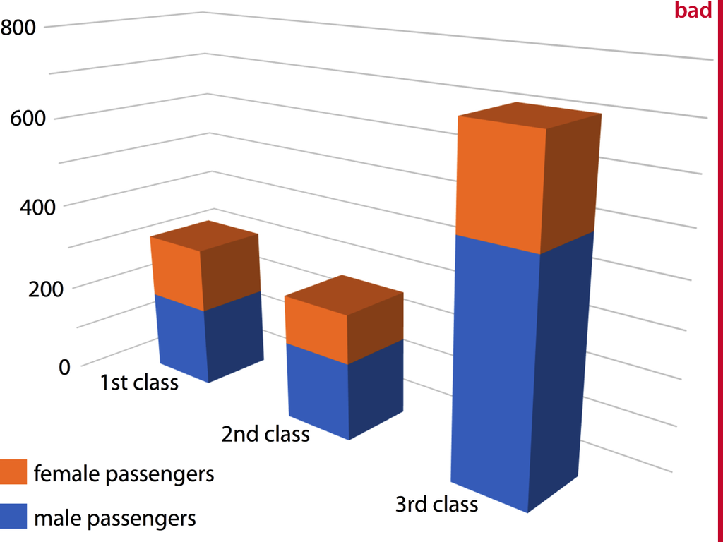

*How many passengers are in first class? How many male passengers are in 3rd class?* Let’s recreate this plot without the gratuitous 3D.

### Titanic Example

The titanic data set

```r
titanic <- tribble(
  ~Class, ~Sex, ~n,
  "1st class", "female passengers", 144,
  "1st class", "male passengers", 179,
  "2nd class", "female passengers", 106,
  "2nd class", "male passengers", 171,
  "3rd class", "female passengers", 216,
  "3rd class", "male passengers", 493
)
```

Recreate the 3D plot in 2D.

```r
ggplot(titanic, aes(x = Class, y = n, fill = Sex)) +
  geom_col() +
  scale_y_continuous(breaks = seq(0, 800, 100)) +
  geom_text(aes(label = n), position = position_stack(0.5))
```

[figure not shown]

# Guideline 3: Integrate the Graphics and Text

1. Remove legends when possible and label data directly
2. Write an active title like a newspaper headline
3. Add explainers

`labs()` adds title, subtitle, caption, and tag to ggplot2 objects. It can also be used to overwrite x, y, and legend titles. Use NULL to remove a label entirely (not `""`).

Visualizing Crime Incidence Throughout the Day

[figure not shown]

# Guideline 3 continue

#### Steps for Graphing Trend of Crime Incidences Throughout the Day

Step 1: Deal with time and date using functions from **lubridate** package

- `TIME.OCCURRED` is in the format `08:15:00`, which corresponds to hour:minute:second. Thus

```r
hms("08:15:00") # Transforms a character to specified number of hours, minutes, and seconds
```

```
## [1] "8H 15M 0S"
```

```r
hour(hms("08:15:00")) #Get hours component
```

```
## [1] 8
```

- Similarly, we can get year, month, day information using `year(mdy())`.
- `DATE.OCCURRED` is in the format “02/10/2010”, which corresponds to month/day/year.

```r
mdy("02/10/2010")
```

```
## [1] "2010-02-10"
```

```r
year(mdy("02/10/2010"))
```

```
## [1] 2010
```

Step 2: Create variable `Time_of_Day` with Early Morning, Morning, Afternoon, and Evening categories.

```r
UC <- UC %>%
  mutate(Hour.occ = hour(hms(TIME.OCCURRED)),
         Time_of_Day = case_when(
           Hour.occ >0 & Hour.occ<=6 ~ "Early Morning",
           Hour.occ>6 & Hour.occ <=12 ~ "Morning",
           Hour.occ>12 & Hour.occ <=18 ~ "Afternoon",
           Hour.occ>18 & Hour.occ<=24 | Hour.occ ==0 ~ "Evening"
         ))
```

Step 3: Specify the order of the levels for Time_of_Day.

```r
UC$Time_of_Day <- factor(UC$Time_of_Day, levels=c("Early Morning", "Morning", "Afternoon", "Evening"))
```

Step 4: Draw barplot for `Time_of_Day`. Add count on the bars using `geom_text(aes(label=n))` and adjust position, color, and font size.

```r
UC %>%
  count(Time_of_Day, WEAPON) %>%
  ggplot(aes(x=Time_of_Day, y=n,  fill=WEAPON)) +
  geom_col()+
  geom_text(aes(label = n),
            position = position_stack(0.5),
            color = "white",
            size=3)
```

Step 5: Add a newspaper like headline with labs(title = ““).

Step 6: Add the sources of the data with `caption = "Data from Urbana's Open Data website"` in labs().

Step 7: Remove x and y labels and the legend title in labs(). Change `labs()` to the following code

```r
labs(x = NULL,
       y = NULL,
       fill = NULL,
       title = "Number of <span style = 'color:#00BFC4;'>with weapon</span> and <span style = 'color:#F8766D;'>without weapon </span>criminal incidents",
              subtitle = "(Increased criminal activity during afternoon and evening hours)",
       caption = "Data from Urbana's Open Data website")+
  theme_minimal()+
  theme(plot.title = element_markdown(hjust = 0.5)) +
  guides(fill = "none")
```

Step 8: Install ggtext with install.packages(“ggtext”) and load the package with library(ggtext).

Step 9: Add the following code:

```r
theme_minimal() +
  theme(plot.title = element_markdown())
```

Step 10: Add guides(fill = “none”) to remove the legend.

```r
library(ggtext)
UC <- UC %>%
  mutate(Hour.occ = hour(hms(TIME.OCCURRED)),
         Time_of_Day = case_when(
           Hour.occ >0 & Hour.occ<=6 ~ "Early Morning",
           Hour.occ>6 & Hour.occ <=12 ~ "Morning",
           Hour.occ>12 & Hour.occ <=18 ~ "Afternoon",
           Hour.occ>18 & Hour.occ<=24 | Hour.occ ==0 ~ "Evening"
         ))

UC$Time_of_Day <- factor(UC$Time_of_Day, levels=c("Early Morning", "Morning", "Afternoon", "Evening"))


UC %>%
  count(Time_of_Day, WEAPON) %>%
  ggplot(aes(x=Time_of_Day, y=n,  fill=WEAPON)) +
  geom_col()+
  geom_text(aes(label = n),
            position = position_stack(0.5),
            color = "white",
            size=3)+
  labs(x = NULL,
       y = NULL,
       fill = NULL,
       title = "Number of <span style = 'color:#00BFC4;'>with weapon</span> and <span style = 'color:#F8766D;'>without weapon </span>criminal incidents",
              subtitle = "(Increased criminal activity during afternoon and evening hours)",
       caption = "Data from Urbana's Open Data website")+
  theme_minimal()+
  theme(plot.title = element_markdown(hjust = 0.5)) +
  guides(fill = "none")
```

[figure not shown]

# Guideline 4: Avoid the Spaghetti Chart

> “Sometimes we face the challenge of including lots of data in a single graph but we don’t need to try to pack everything into a single graph.

1. Arrange the small multiples in a logical order
2. Use the same layout, size, font, and color in each small multiple

Graphs Comparison: Yearly trends in the top six non-traffic offenses crimes with and without using facet

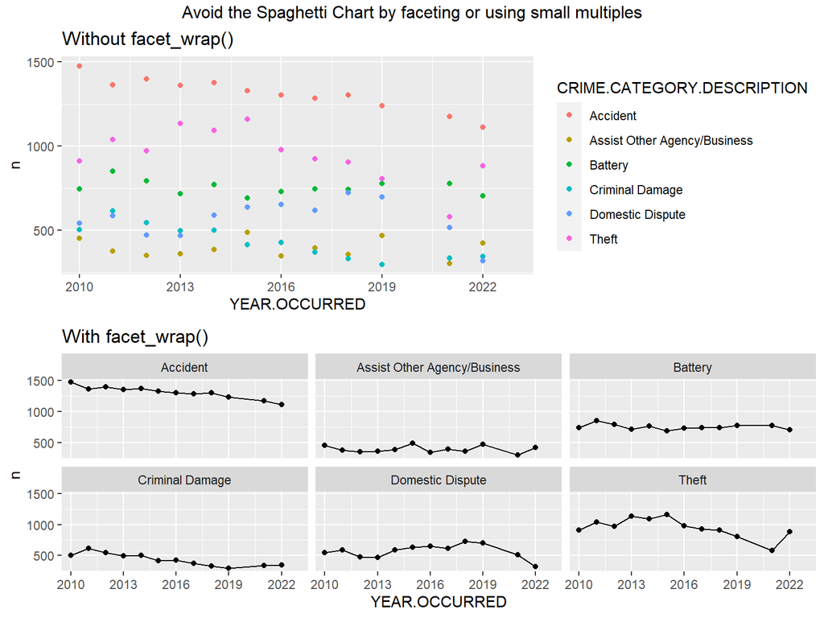

# Guideline 4 continue

#### Steps for graphing the yearly trends in the top six non-traffic offenses crimes

Step 1: Find the top seven crimes (including traffic offenses)

```r
UC %>%
  filter(!is.na(CRIME.CATEGORY.DESCRIPTION)) %>%
  count(CRIME.CATEGORY.DESCRIPTION) %>%
  arrange(desc(n)) %>%
  head(7) %>%
  pull(CRIME.CATEGORY.DESCRIPTION)
```

```
## [1] "Traffic Offenses"             "Accident"
## [3] "Theft"                        "Battery"
## [5] "Domestic Dispute"             "Criminal Damage"
## [7] "Assist Other Agency/Business"
```

Step 2: Remove Traffic Offenses group before plotting. Color the points using Crime Category.

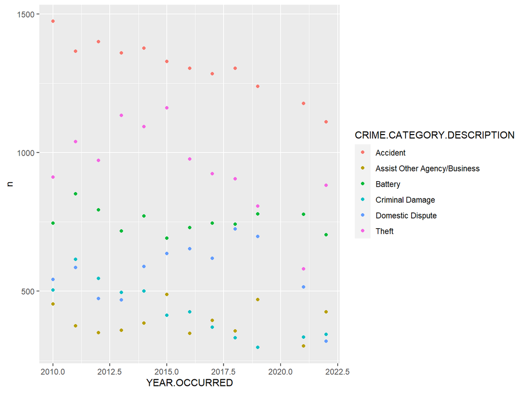

```r
UC %>%
  filter(CRIME.CATEGORY.DESCRIPTION %in% High_Crime_category &
           CRIME.CATEGORY.DESCRIPTION !="Traffic Offenses") %>%
  count(YEAR.OCCURRED, CRIME.CATEGORY.DESCRIPTION) %>%
  ggplot(aes(x=YEAR.OCCURRED, y = n, color=CRIME.CATEGORY.DESCRIPTION))+
  geom_point()
```

Step 3: Add the following code to clean up the x-axis

```r
scale_x_continuous(expand = expand_scale(mult = c(0.002, 0)),
                   breaks = c(seq(2010, 2023, 3)),
                   limits = c(2009.5, 2023.5))
```

Step 4: Repeat the code and add `facet_wrap(~CRIME.CATEGORY.DESCRIPTION)`. Step 5: Use `grid.arrange()` in `gridExtra` package to arrange multiple plots on a page for comparison.

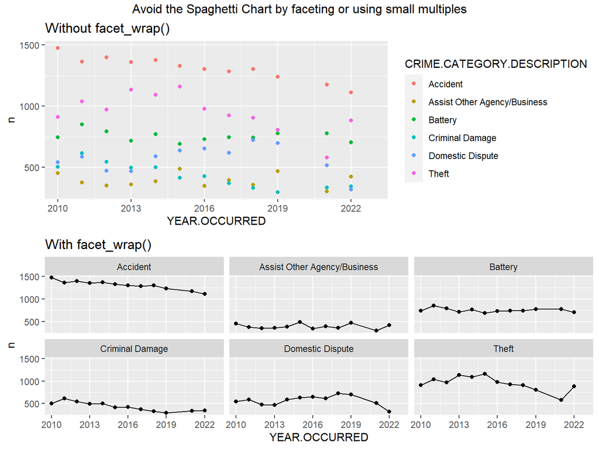

```r
High_Crime_category <-
  UC %>%
  filter(!is.na(CRIME.CATEGORY.DESCRIPTION)) %>%
  count(CRIME.CATEGORY.DESCRIPTION) %>%
  arrange(desc(n)) %>%
  head(7) %>%
  pull(CRIME.CATEGORY.DESCRIPTION)

p1 <- UC %>%
  filter(CRIME.CATEGORY.DESCRIPTION %in% High_Crime_category &
           CRIME.CATEGORY.DESCRIPTION !="Traffic Offenses") %>%
  count(YEAR.OCCURRED, CRIME.CATEGORY.DESCRIPTION) %>%
  ggplot(aes(x=YEAR.OCCURRED, y = n, color=CRIME.CATEGORY.DESCRIPTION))+
  geom_point() +
  labs(title = "Without facet_wrap()")+
  scale_x_continuous(expand = expand_scale(mult = c(0.002, 0)),
                     breaks = c(seq(2010, 2023, 3)),
                     limits = c(2009.5, 2023.5))
p2 <- UC %>%
  filter(CRIME.CATEGORY.DESCRIPTION %in% High_Crime_category &
           CRIME.CATEGORY.DESCRIPTION !="Traffic Offenses") %>%
  count(YEAR.OCCURRED, CRIME.CATEGORY.DESCRIPTION) %>%
  ggplot(aes(x=YEAR.OCCURRED, y = n))+
  geom_point(show.legend = FALSE)+
  geom_line(show.legend = FALSE)+
  scale_x_continuous(expand = expand_scale(mult = c(0.002, 0)),
                     breaks = c(seq(2010, 2023, 3)),
                     limits = c(2009.5, 2023.5))+
  facet_wrap(~CRIME.CATEGORY.DESCRIPTION)+
  labs(title = "With facet_wrap()")

library(grid)
library(gridExtra)
grid.arrange(p1, p2, nrow=2,
             top=textGrob("Avoid the Spaghetti Chart by faceting or using small multiples"))
```

# Guideline 5: Start with Gray

> “Whenever you make a graph, start with all gray data elements. By doing so, you force yourself to be purposeful and strategic in your use of color, labels, and other elements.”

[`library(gghighlight)`](https://cran.r-project.org/web/packages/gghighlight/vignettes/gghighlight.html) complements this idea of starting with gray.

Cumulative Crime Incidence Example

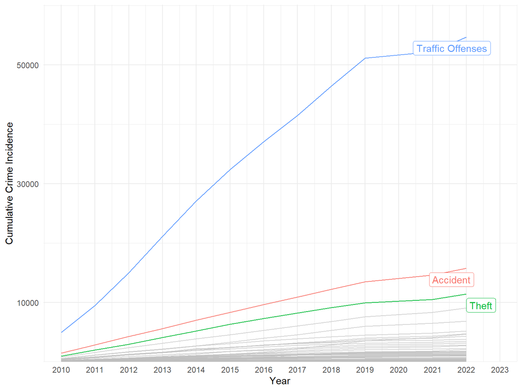

# Guideline 5 continue

#### Steps for Graphing Calculating Cumulative Crime Incidence

Step 1: Compute the cumulative sum of each crime incidence type over the years.

```r
UC.cumsum <- UC %>%
  count(CRIME.CATEGORY.DESCRIPTION, YEAR.OCCURRED) %>%
  group_by(CRIME.CATEGORY.DESCRIPTION) %>%
  mutate(cumsum = cumsum(n))
```

Step 2: Create a line plot with `x = YEAR.OCCURRED`, `y = cumsum`, `group = CRIME.CATEGORY.DESCRIPTION`, and geom_line()

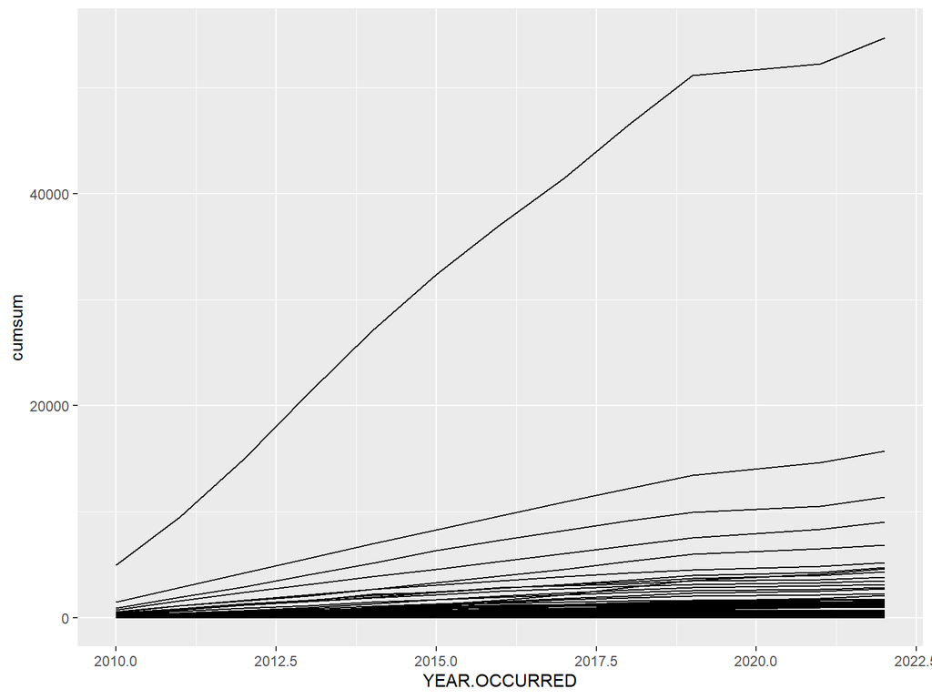

```r
UC.cumsum %>%
  ggplot(aes(YEAR.OCCURRED, cumsum, group =CRIME.CATEGORY.DESCRIPTION))+
  geom_line()
```

**Note:** If we simply create a line graph with `color = CRIME.CATEGORY.DESCRIPTION`, then

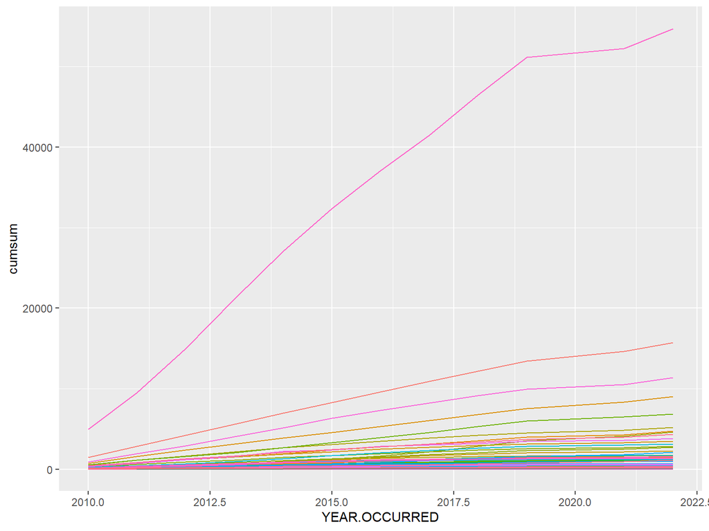

```r
UC.cumsum %>%
  ggplot(aes(YEAR.OCCURRED, cumsum, color =CRIME.CATEGORY.DESCRIPTION))+
  geom_line(show.legend = FALSE)
```

Step 3: Add the following code to clean up the x-axis and y-axis.

```r
scale_x_continuous(expand = expand_scale(mult = c(0.002, 0)),
                   breaks = c(seq(2010, 2023, 1)),
                   limits = c(2009.5, 2023.5)) +
scale_y_continuous(expand = expand_scale(mult = c(0, 0.002)),
                   breaks = seq(1,6,2) * 10000,
                   limits = c(0, 60000))+
labs(x = "Year",
     y = "Cumulative Crime Incidence")
```

Step 4: Suppose we want to highlight the three crime incidence types with the highest occurrences. We can use library(gghighlight). Switch *group* to *color* in your existing code and add `gghighlight(max(cumsum) > 10000)`.

Step 5: Above the data viz, add `theme_minimal()`. Or run `theme_set(theme_minimal())`, which changes the default theme for the entire R session.

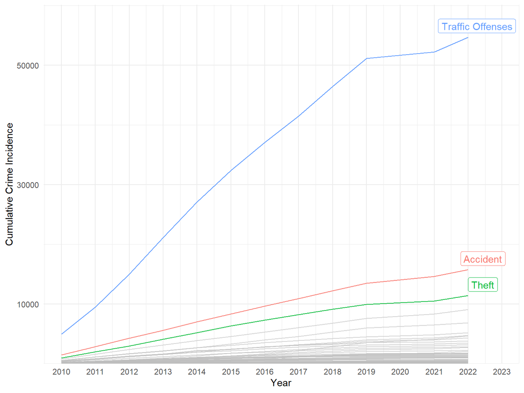

```r
library(gghighlight)

UC %>%
  count(CRIME.CATEGORY.DESCRIPTION, YEAR.OCCURRED) %>%
  group_by(CRIME.CATEGORY.DESCRIPTION) %>%
  mutate(cumsum = cumsum(n)) %>%
  ggplot(aes(YEAR.OCCURRED, cumsum, color=CRIME.CATEGORY.DESCRIPTION))+
  geom_line()+
  scale_x_continuous(expand = expand_scale(mult = c(0.002, 0)),
                     breaks = c(seq(2010, 2023, 1)),
                     limits = c(2009.5, 2023.5)) +
  scale_y_continuous(expand = expand_scale(mult = c(0, 0.002)),
                     breaks = seq(1,6,2) * 10000,
                     limits = c(0, 60000))+
  labs(x = "Year",
       y = "Cumulative Crime Incidence")+
  gghighlight(max(cumsum) > 10000)+
  theme_minimal()
```

# Resources

### Major Recources

- https://github.com/awunderground/sdss2021_data-viz-training
- By Aaron Williams, Senior Data Scientist at the Urban Institute

### Rstudio Cheatsheets

- https://www.rstudio.com/resources/cheatsheets/

### More tutorial videos from freeCodeCamp.org on YouTube

- https://www.youtube.com/watch?v=_V8eKsto3Ug&t=4s

### Reference Books

#### Free online books with excellent material

- R for Data Science: https://r4ds.had.co.nz/index.html
- Hands-on Programming with R: https://rstudio-education.github.io/hopr/
- R Graphics Cookbook: https://r-graphics.org/
- Fundamentals of Data Visualization: https://clauswilke.com/dataviz/

#### Other books

- Better Data Visualizations: A Guide for Scholars, Researchers, and Wonks, by Jon Schwabish
- Statistical Inference via Data Science: A Modern Dive into R and the Tidyverse, by Chester Ismay, Albert Y. Kim

# Thank you! And… Questions?

Contact Information:

- Dr. Weijia Jia
  - Clinical Assistant Professor
  - Email: wjia@illinois.edu
  - Department of Statistics, UIUC